# chapter3.Rmd

# Week3 Analysis exercise, Ville Turppo 10.11.2020

Reading the data to R. Taking it from the internet incase I have made some mistakes before. Colnames command to see the variable names.

```r
AA <- read.table("http://s3.amazonaws.com/assets.datacamp.com/production/course_2218/datasets/alc.txt", sep = "," , header = TRUE)
colnames(AA)
```

```
##  [1] "school"     "sex"        "age"        "address"    "famsize"
##  [6] "Pstatus"    "Medu"       "Fedu"       "Mjob"       "Fjob"
## [11] "reason"     "nursery"    "internet"   "guardian"   "traveltime"
## [16] "studytime"  "failures"   "schoolsup"  "famsup"     "paid"
## [21] "activities" "higher"     "romantic"   "famrel"     "freetime"
## [26] "goout"      "Dalc"       "Walc"       "health"     "absences"
## [31] "G1"         "G2"         "G3"         "alc_use"    "high_use"
```

Dim command shows that there are 382 rows = participants and 35 variables.

```r
dim (AA)
```

```
## [1] 382  35
```

Logistic regression for factors relating to higher alcohol consumption.I choose to use sex, absences,failures and address. My hypothesis: alco, absences and failures are related. Alco, sex and address are not related.

```r
m <- glm(high_use ~ failures + absences + sex + address, data = AA, family = "binomial")
```

Extracting coefficients and then intrepeting them ass Odds rations And computing confidence intervals

```r
library(tidyr)
library(dplyr); library(ggplot2)
```

Installed the packages

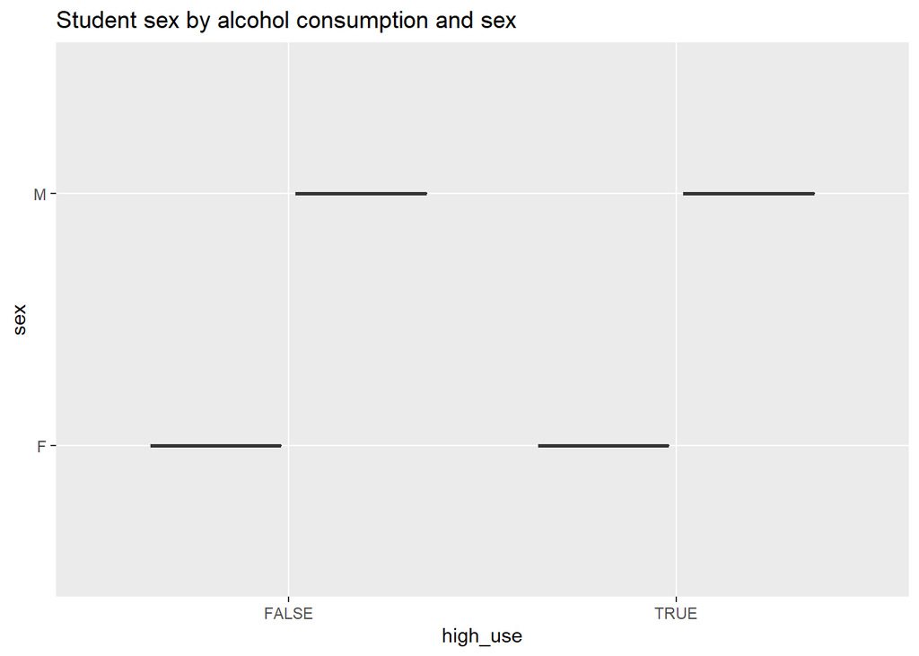

```r
g1 <- ggplot(AA, aes(x = high_use, y = sex))
g2 <- ggplot(AA, aes(x = high_use, y = absences))
g3 <- ggplot(AA, aes(x = high_use, y = failures))
g4 <- ggplot(AA, aes(x = high_use, y = address))

g1 + geom_boxplot() + ggtitle("Student sex by alcohol consumption and sex")
```

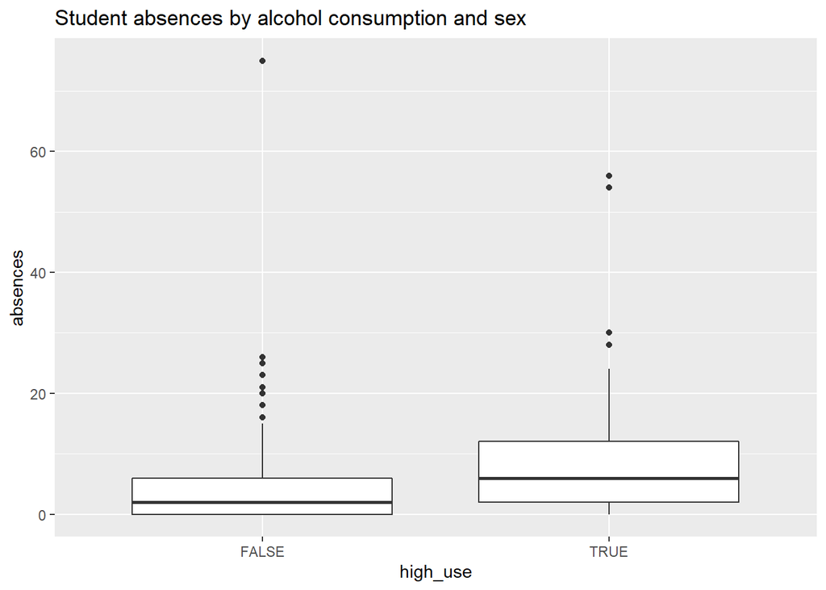

```r
g2 + geom_boxplot() + ggtitle("Student absences by alcohol consumption and sex")
```

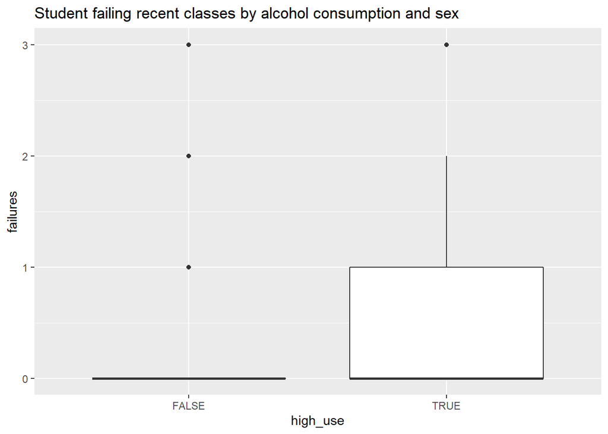

```r
g3 + geom_boxplot() + ggtitle("Student failing recent classes by alcohol consumption and sex")
```

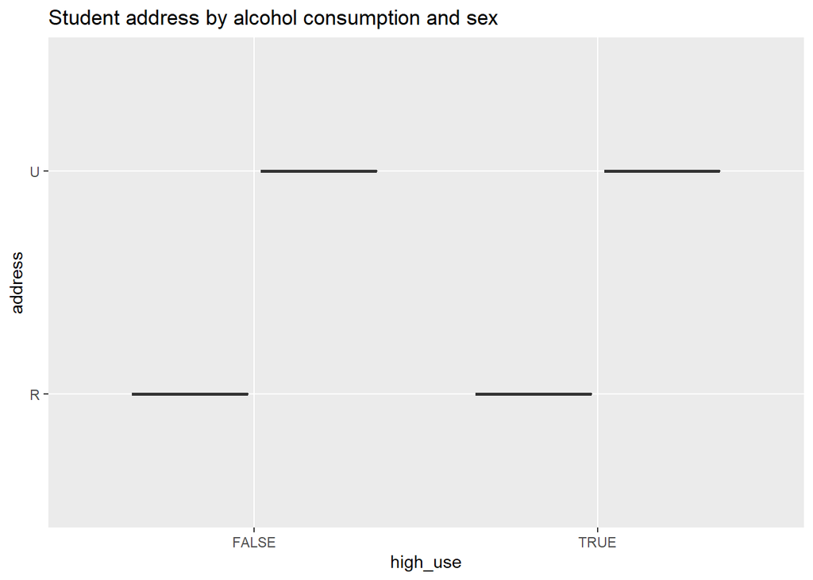

```r
g4 + geom_boxplot() + ggtitle("Student address by alcohol consumption and sex")
```

```r
FAIL2 <- table(AA$failures, AA$high_use)
FAIL2
```

```
##
##     FALSE TRUE
##   0   234   82
##   1    22   16
##   2     5    6
##   3     9    8
```

```r
seex <- table(AA$sex, AA$high_use)
seex
```

```
##
##     FALSE TRUE
##   F   157   41
##   M   113   71
```

```r
add <- table(AA$address, AA$high_use)
add
```

```
##
##     FALSE TRUE
##   R    50   31
##   U   220   81
```

```r
X <- glm(high_use ~ failures + absences + sex, data = AA, family = "binomial")
```

Predicting the probability of high_use

```r
probabilities <- predict(X, type = "response")
```

Adding the predicted probalities to data AA

```r
AA <- mutate(AA, probability = probabilities)
```

Using the probabilities to predict high_use

```r
AA <- mutate(AA, prediction = probability > 0.5)
```

Making Crosstabulation of the target variable vs predictions

```r
table(high_use = AA$high_use, prediction = AA$prediction)
```

```
##         prediction
## high_use FALSE TRUE
##    FALSE   258   12
##    TRUE     86   26
```

Plotting the same results

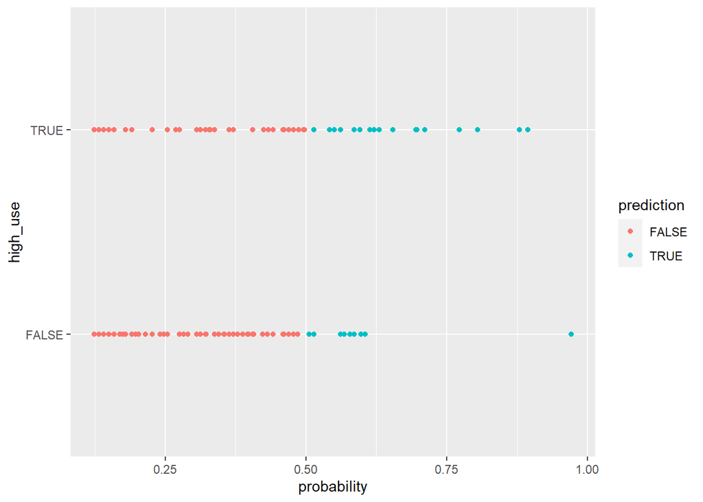

```r
g <- ggplot(AA, aes(x = probability, y = high_use, col = prediction))
g + geom_point()
```

As seen in both, the crosstabs and the plot. Lot of FALSE predictions were infact TRUE. FALSE predictions were more accurate since only 12 real FALSEs were predicted as high use. Sensitivity 26/112 * 100 = 23% and Specifity 258/270 *100 = 96%. Meaning the model is not good in predicting high alcohol use.

Bonus 10-fold cross-validation Define a loss function (average prediction error)

```r
loss_func <- function(class, prob) {
  n_wrong <- abs(class - prob) > 0.5
  mean(n_wrong)
}
```

The average number of wrong predictions in the data

```r
loss_func(class = AA$high_use, prob = AA$probability)
```

```
## [1] 0.2565445
```

K-fold cross-validation

```r
library(boot)
CS <- cv.glm(data = AA, cost = loss_func, glmfit = X, K = 10)
```

Average number of wrong predictions in the cross validation

```r
CS$delta[1]
```

```
## [1] 0.2591623
```